# Guided Project: Credit Card Customer Segmentation

In this guided project, we’ll play the role of a data scientist working for a credit card company. We’ve been given a dataset containing information about the company’s clients and asked to help segment them into different groups in order to apply different business strategies for each type of customer.

The company expects to receive a group for each client and also an explanation of the characteristics of each group and what are the main points that make them different.

In a planning meeting with the Data Science coordinator, it was decided that we should use the K-means algorithm to segment the data.

In order to use the algorithm properly and achieve all the goals that the company has set for us, we'll go through the following steps:

- Analyse the dataset;
- Prepare the data for modeling;
- Find an appropriate number of clusters;
- Segment the data;
- Interpret and explain the results.

We'll start by importing the packages we'll use.

```python
from sklearn.cluster import KMeans
from sklearn.preprocessing import StandardScaler
import seaborn as sns
import pandas as pd
import matplotlib.pyplot as plt
```

```
(10127, 14)
<class 'pandas.core.frame.DataFrame'>
RangeIndex: 10127 entries, 0 to 10126
Data columns (total 14 columns):
 #   Column                    Non-Null Count  Dtype
---  ------                    --------------  -----
 0   customer_id               10127 non-null  int64
 1   age                       10127 non-null  int64
 2   gender                    10127 non-null  object
 3   dependent_count           10127 non-null  int64
 4   education_level           10127 non-null  object
 5   marital_status            10127 non-null  object
 6   estimated_income          10127 non-null  int64
 7   months_on_book            10127 non-null  int64
 8   total_relationship_count  10127 non-null  int64
 9   months_inactive_12_mon    10127 non-null  int64
 10  credit_limit              10127 non-null  float64
 11  total_trans_amount        10127 non-null  int64
 12  total_trans_count         10127 non-null  int64
 13  avg_utilization_ratio     10127 non-null  float64
dtypes: float64(2), int64(9), object(3)
memory usage: 1.1+ MB
None
```

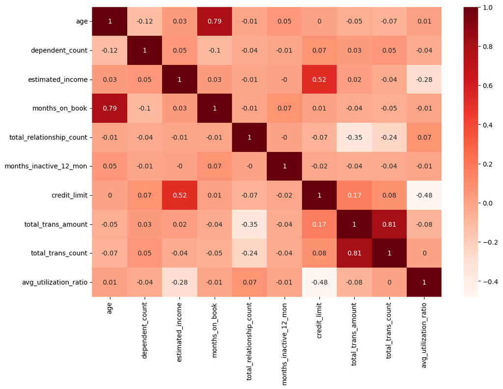

```python
data1=pd.read_csv('customer_segmentation.csv')
print(data1.shape)
print(data1.info())
fig,ax=plt.subplots(figsize=(12,8))
sns.heatmap(data1.drop('customer_id',axis=1).corr().round(2),cmap='Reds',annot=True,ax=ax)
```

Most of the variables present weak correlations between each other, but there are some we can highlight:

- Age is strongly correlated with how long the person has been a customer (months_on_book);
- Credit limit is positively correlated with the estimated income and negatively correlated with the average utilization ratio;
- The total number of transactions (total_trans_count) is strongly correlated with the total amount transitioned (total_trans_amount).

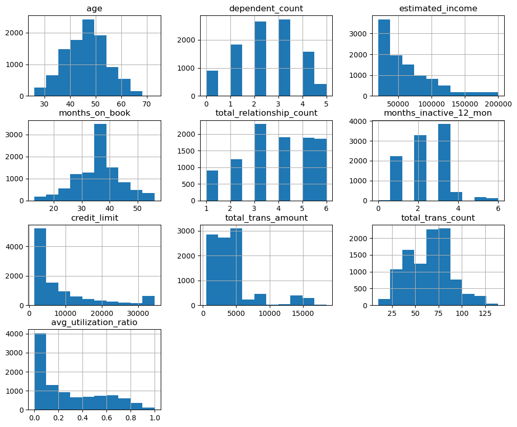

```python
fig,ax = plt.subplots(figsize=(12,10))
data1.drop('customer_id',axis=1).hist(ax=ax)
# plt.tight_layout()
plt.show()
```

Regarding distributions, we have a couple of them closer to a normal distribution, but most of them are skewed.

# Feature Engineering

We're now dealing with the 3 categorical variables.

The gender column is the easiest one. We'll use a lambda function to replace the values with ones and zeros.

We'll also be able to transform the education_level column to numeric. We'll use the replace() method to perform this task. This method will assign a value to each level of education:

- Uneducated - 0
- High School - 1
- College - 2
- Graduate - 3
- Post-Graduate - 4
- Doctorate - 5

Unfortunately, we can't do the same for this marital_status column as there is no level of magnitude between "Single", "Married" or "Divorced", for example. We can't say that any of them is higher or better than the others. Therefore, we'll use one-hot-encoding to create dummy variables from this column and then drop the original variable.

```python
data2=data1.copy()
print(data2['gender'].value_counts())
data2['gender']=data2['gender'].apply(lambda e: 1 if e== 'M' else 0)
edu_map={'Uneducated' : 0, 'High School' : 1,'College' : 2,'Graduate' : 3,'Post-Graduate' : 4,'Doctorate' : 5}
```

```
F    5358
M    4769
Name: gender, dtype: int64
```

```python
print(data2['education_level'].value_counts())
data2['education_level']=data2['education_level'].map(edu_map)
print(data2['education_level'].value_counts())
```

```
Graduate         3685
High School      2351
Uneducated       1755
College          1192
Post-Graduate     616
Doctorate         528
Name: education_level, dtype: int64
3    3685
1    2351
0    1755
2    1192
4     616
5     528
Name: education_level, dtype: int64
```

```python
data3=pd.get_dummies(data2,columns=['marital_status'],drop_first=True)
print(data3.shape)
data3.head()
```

```
(10127, 16)
```

|  | customer_id | age | gender | dependent_count | education_level | estimated_income | months_on_book | total_relationship_count | months_inactive_12_mon | credit_limit | total_trans_amount | total_trans_count | avg_utilization_ratio | marital_status_Married | marital_status_Single | marital_status_Unknown |
| --- | --- | --- | --- | --- | --- | --- | --- | --- | --- | --- | --- | --- | --- | --- | --- | --- |
| 0 | 768805383 | 45 | 1 | 3 | 1 | 69000 | 39 | 5 | 1 | 12691.0 | 1144 | 42 | 0.061 | 1 | 0 | 0 |
| 1 | 818770008 | 49 | 0 | 5 | 3 | 24000 | 44 | 6 | 1 | 8256.0 | 1291 | 33 | 0.105 | 0 | 1 | 0 |
| 2 | 713982108 | 51 | 1 | 3 | 3 | 93000 | 36 | 4 | 1 | 3418.0 | 1887 | 20 | 0.000 | 1 | 0 | 0 |
| 3 | 769911858 | 40 | 0 | 4 | 1 | 37000 | 34 | 3 | 4 | 3313.0 | 1171 | 20 | 0.760 | 0 | 0 | 1 |
| 4 | 709106358 | 40 | 1 | 3 | 0 | 65000 | 21 | 5 | 1 | 4716.0 | 816 | 28 | 0.000 | 1 | 0 | 0 |

# Scaling the Data

First, we need to standardize the dataset. We'll use scikit-learn's StandardScaler() for this task.

```python
data4=data3.drop('customer_id',axis=1)
print('customer_id' in data4.columns)
scaler = StandardScaler()
```

```
False
```

```python
data4_scaled=scaler.fit_transform(data4)
```

```python
data5=pd.DataFrame(data4_scaled)
inertias=[]
for i in range(1,12):
    model=KMeans(n_clusters=i+1)
    clusters=model.fit_predict(data5)
    inertias.append(model.inertia_)
```

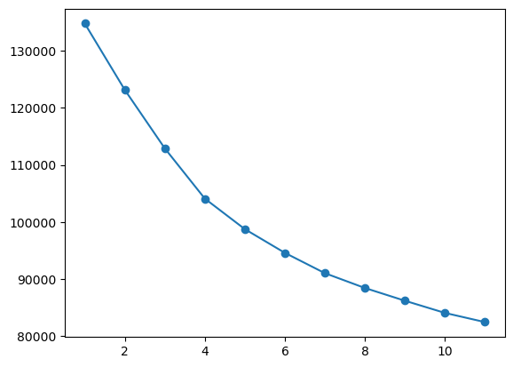

```python
plt.plot(range(1,12),inertias,marker='o')
plt.show()
```

it looks like the rate of decreasing of the inertia slows down between 5 and 6 clusters. We'll use 6 clusters to move on.

```python
model=KMeans(n_clusters=6)
cluster=model.fit_predict(data5)
cluster
```

```
array([3, 1, 3, ..., 0, 4, 0], dtype=int32)
```

```python
data1['CLUSTER']=cluster
data1
```

|  | customer_id | age | gender | dependent_count | education_level | marital_status | estimated_income | months_on_book | total_relationship_count | months_inactive_12_mon | credit_limit | total_trans_amount | total_trans_count | avg_utilization_ratio | CLUSTER |
| --- | --- | --- | --- | --- | --- | --- | --- | --- | --- | --- | --- | --- | --- | --- | --- |
| 0 | 768805383 | 45 | M | 3 | High School | Married | 69000 | 39 | 5 | 1 | 12691.0 | 1144 | 42 | 0.061 | 3 |
| 1 | 818770008 | 49 | F | 5 | Graduate | Single | 24000 | 44 | 6 | 1 | 8256.0 | 1291 | 33 | 0.105 | 1 |
| 2 | 713982108 | 51 | M | 3 | Graduate | Married | 93000 | 36 | 4 | 1 | 3418.0 | 1887 | 20 | 0.000 | 3 |
| 3 | 769911858 | 40 | F | 4 | High School | Unknown | 37000 | 34 | 3 | 4 | 3313.0 | 1171 | 20 | 0.760 | 4 |
| 4 | 709106358 | 40 | M | 3 | Uneducated | Married | 65000 | 21 | 5 | 1 | 4716.0 | 816 | 28 | 0.000 | 0 |
| ... | ... | ... | ... | ... | ... | ... | ... | ... | ... | ... | ... | ... | ... | ... | ... |
| 10122 | 772366833 | 50 | M | 2 | Graduate | Single | 51000 | 40 | 3 | 2 | 4003.0 | 15476 | 117 | 0.462 | 2 |
| 10123 | 710638233 | 41 | M | 2 | Graduate | Divorced | 40000 | 25 | 4 | 2 | 4277.0 | 8764 | 69 | 0.511 | 0 |
| 10124 | 716506083 | 44 | F | 1 | High School | Married | 33000 | 36 | 5 | 3 | 5409.0 | 10291 | 60 | 0.000 | 0 |
| 10125 | 717406983 | 30 | M | 2 | Graduate | Unknown | 47000 | 36 | 4 | 3 | 5281.0 | 8395 | 62 | 0.000 | 4 |
| 10126 | 714337233 | 43 | F | 2 | Graduate | Married | 36000 | 25 | 6 | 2 | 10388.0 | 10294 | 61 | 0.189 | 0 |

10127 rows × 15 columns

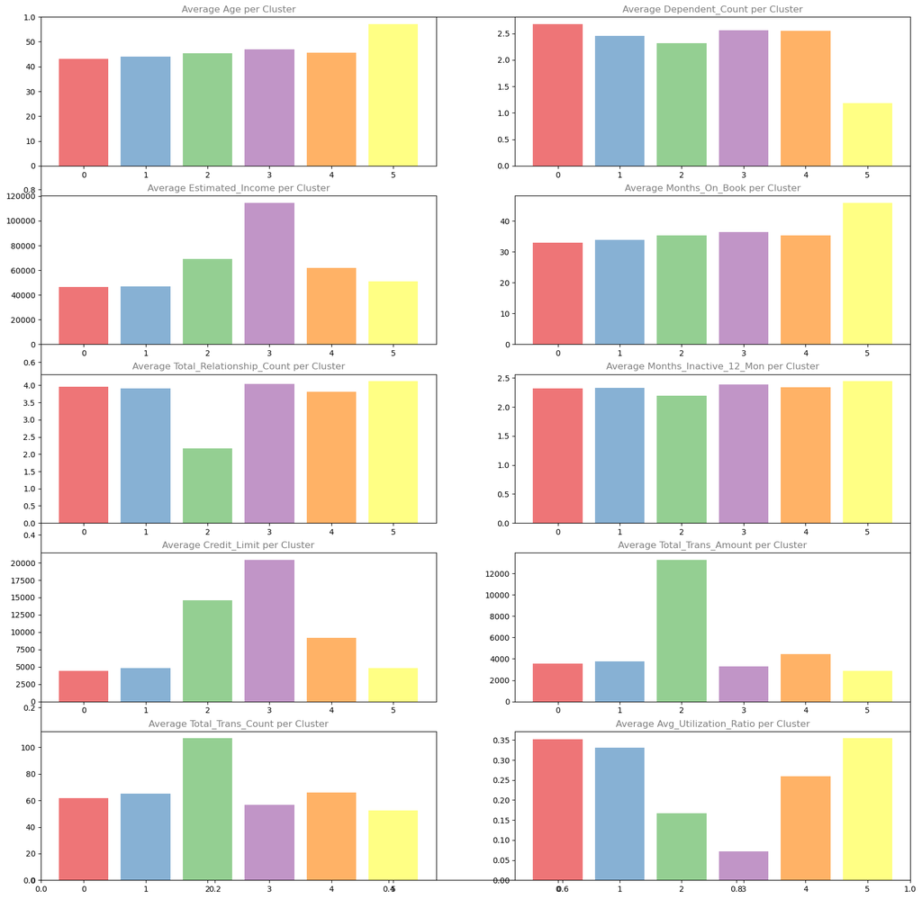

```python
import numpy as np
numeric_columns=data1.select_dtypes(include=np.number).drop(['customer_id', 'CLUSTER'], axis=1).columns
fig, axs = plt.subplots(figsize=(20,20))
for i,col in enumerate(numeric_columns):
    df_plot=data1.groupby('CLUSTER').mean()[col]
    ax=fig.add_subplot(5, 2, i+1)
    ax.bar(df_plot.index, df_plot, color=sns.color_palette('Set1'), alpha=0.6)
    ax.set_title(f'Average {col.title()} per Cluster', alpha=0.5)
    ax.xaxis.grid(False)
plt.show()
```

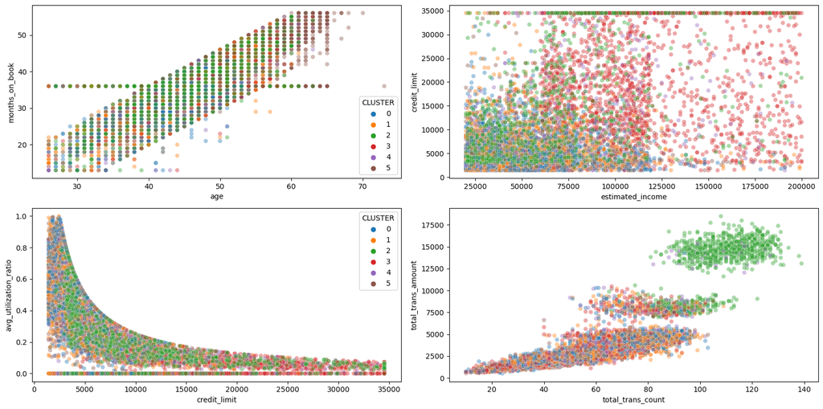

```python
fig, ((ax1, ax2), (ax3, ax4)) = plt.subplots(2, 2, figsize=(16, 8))
sns.scatterplot(x='age', y='months_on_book', hue='CLUSTER', data=data1, palette='tab10', alpha=0.4, ax=ax1)
sns.scatterplot(x='estimated_income', y='credit_limit', hue='CLUSTER', data=data1, palette='tab10', alpha=0.4, ax=ax2, legend=False)
sns.scatterplot(x='credit_limit', y='avg_utilization_ratio', hue='CLUSTER', data=data1, palette='tab10', alpha=0.4, ax=ax3)
sns.scatterplot(x='total_trans_count', y='total_trans_amount', hue='CLUSTER', data=data1, palette='tab10', alpha=0.4, ax=ax4, legend=False)

plt.tight_layout()
plt.show()
```

We can draw some early conclusions considering only the numeric variables.

For the categorical columns, we'll plot the percentual distribution of each variable in each cluster. This will allow us to verify if a particular cluster is mostly composed of men, or of married people only, for example.

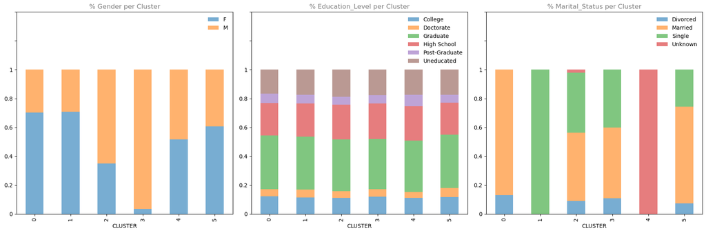

```python
cat_columns = data1.select_dtypes(include=['object'])

fig = plt.figure(figsize=(18, 6))
for i, col in enumerate(cat_columns):
    plot_df = pd.crosstab(index=data1['CLUSTER'], columns=data1[col], values=data1[col], aggfunc='size', normalize='index')
    ax = fig.add_subplot(1, 3, i+1)
    plot_df.plot.bar(stacked=True, ax=ax, alpha=0.6)
    ax.set_title(f'% {col.title()} per Cluster', alpha=0.5)

    ax.set_ylim(0, 1.4)
    ax.legend(frameon=False)
    ax.xaxis.grid(False)

    labels = [0, 0.2, 0.4, 0.6, 0.8, 1]
    ax.set_yticklabels(labels)

plt.tight_layout()
plt.show()
```

Considering the categorical variables, we notice that the education level is well divided between clusters.

# Conclusion

In the end, we have the list of customers with a cluster assigned to each one.

Insight: People with high volume spent on the card, but do not use it on a daily basis. Could be incentivized to use it more often.

Characteristics: Mostly women; mostly married; low estimated income; low credit limit; low amount transitioned; high utilization rate.

Insight: Married people (majority women) with low income and limit but use the card too often. Could be given a bit more credit limit.

## Cluster 5

Cluster 5: Mostly married, high age, low dependent count, long time customers, low credit limit, low amount transitioned, high utilization rate.

Insight: Older people and long-time customers. Low credit limit and transactions, but use the card very often. Could receive benefits to spend more money.

## Cluster 1

Cluster 1: Mostly women; 100% single, low estimated income, low credit limit, low amount transitioned, high utilization rate.

Insight: Single (mostly women) people that use their card a lot but have low credit limits and income. Could be given a bit more credit limit.